# Edge Detection

**Key Idea?** Look for strong gradients, and then post-process.

## How are edges caused?

Due to discontinuties in:

1. Surface Normal
2. Surface Color/Appearance
3. Depth
4. Illumination

```python
import numpy as np
import pandas as pd
import matplotlib.pyplot as plt
from scipy import datasets, misc
from PIL import Image
from scipy.ndimage import convolve, correlate, gaussian_filter, filters, laplace
import cv2 as cv
```

## Egdes look like Steep Cliffs in images represented as a function

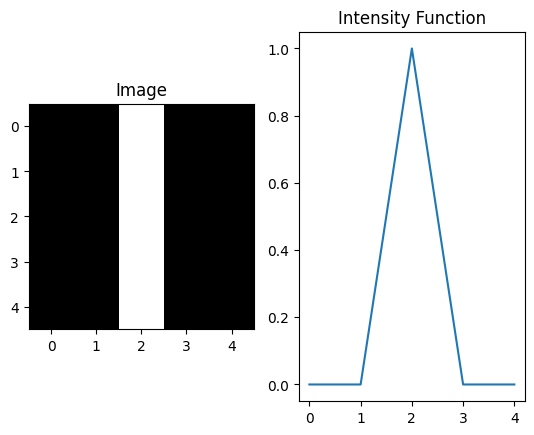

```python
im = np.zeros((5,5))
for i in range(5):
    im[i, 2] = 1
f,ax = plt.subplots(1, 2)
ax[0].imshow(im, cmap='gray')
ax[0].title.set_text("Image")
ax[1].plot(im[0])
ax[1].title.set_text("Intensity Function")
```

## Derivatives with Convolution

For discrete data, we can approximate using finite differences: $\frac{\partial{f(x,y)}}{\partial{x}} \approx \frac{f(x+1, y) - f(x, y)}{1}$

Example of such a filter: $\begin{bmatrix}-1 & 1\end{bmatrix}$, $\begin{bmatrix}-1 \\ 1\end{bmatrix}$, $\begin{bmatrix}1 \\ -1\end{bmatrix}$

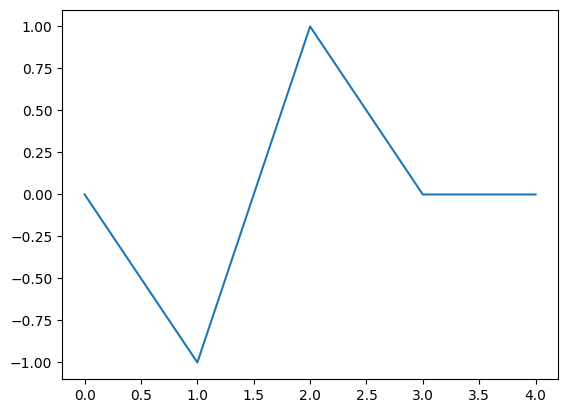

```python
derivative_filter = np.matrix([-1, 1])
derivative_of_image = convolve(im, derivative_filter)
plt.plot(derivative_of_image[0])
```

*The Extrema correspond to the edges*

## Standard Edge Detection Filters

```python
ascent = datasets.ascent().astype('int32')
```

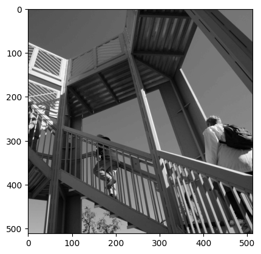

```python
plt.imshow(ascent, cmap='gray')
```

### Sobel/Roberts/Prewitt Edge Detection

Prewitt (Vertical Version): $\begin{bmatrix} -1 & 0 & 1 \\ -1 & 0 & 1 \\ -1 & 0 & 1 \end{bmatrix}$  
Sobel (Vertical Version): $\begin{bmatrix} -1 & 0 & 1 \\ -2 & 0 & 2 \\ -1 & 0 & 1 \end{bmatrix}$  
Roberts (Diagnol Edges Detection): $\begin{bmatrix} 0 & 1 \\ -1 & 0 \end{bmatrix}$

The above given version of *Prewitt & Sobel* detect edges going from **black** to white. If the 1st and 3rd columns are interchanged the filters would detect edges going from white to **black**  
Assumption: $0 \rightarrow black$, $255 \rightarrow white$

```python
prewitt = np.matrix([[-1,0,1], [-1,0,1], [-1,0,1]])
sobel = np.matrix([[1,0,-1], [2,0,-2], [1, 0, -1]])
roberts = np.matrix([[0, 1], [-1, 0]])
```

```python
sobel_v = convolve(ascent, sobel)
sobel_h = convolve(ascent, sobel.T)
magnitude = np.sqrt(sobel_v**2 + sobel_h**2)
magnitude *= 255 / np.max(magnitude) # To bring the max of magnitude to 255
```

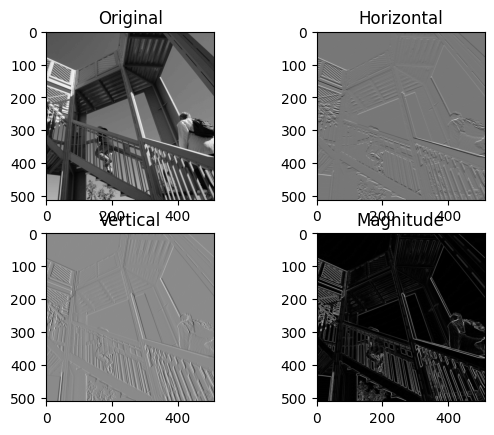

```python
f, ax = plt.subplots(2,2)
ax[0,0].imshow(ascent, cmap='gray')
ax[0,0].title.set_text("Original")
ax[0,1].imshow(sobel_h, cmap='gray')
ax[0,1].title.set_text("Horizontal")
ax[1,0].imshow(sobel_v, cmap='gray')
ax[1,0].title.set_text("Vertical")
ax[1,1].imshow(magnitude, cmap='gray')
ax[1,1].title.set_text("Magnitude")
```

## Image Graidents

- **Graident** of an Image: $\nabla{f} = [\frac{\partial{f}}{\partial{x}}, \frac{\partial{f}}{\partial{y}}]$
- If $\nabla{f} = [\frac{\partial{f}}{\partial{x}}, 0]$, then there is a no change in the image intensity in the y-direction and vice versa.
- **Graident/Edge Strength**: $\sqrt{(\frac{\partial{f}}{\partial{x}})^2 + (\frac{\partial{f}}{\partial{y}})^2}$
- **Orientation of Gradient**: $\theta = tan^{-1}({\frac{\frac{\partial{f}}{\partial{x}}} {\frac{\partial{f}}{\partial{y}}}})$

## Effect of Noise?

Possible Solution:

- 1. Smooth First
- 2. Look for Peaks in $\frac{d(f * g)}{dx}$

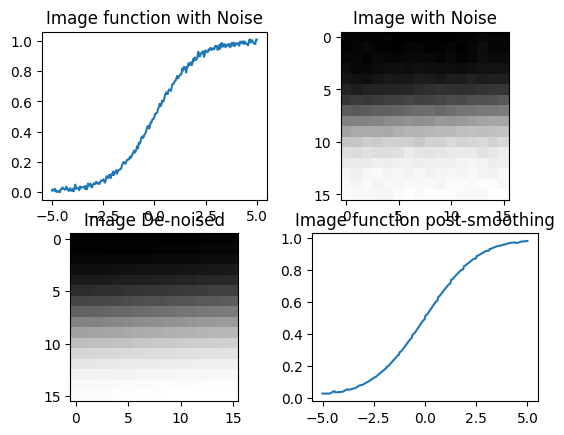

```python
x = np.linspace(-5, 5, 256)
denoised_y = 1/(1+np.exp(-x))
noise = np.random.normal(0,0.01,256)
y  = denoised_y + noise
to_image = y.reshape(16, 16)
post_gaussian = gaussian_filter(to_image, sigma=2)
to_function = post_gaussian.reshape(256,)
f, ax = plt.subplots(2, 2)
ax[0,0].plot(x, y)
ax[0,0].title.set_text("Image function with Noise")
ax[0,1].imshow(to_image, cmap='gray')
ax[0,1].title.set_text("Image with Noise")
ax[1,0].imshow(post_gaussian, cmap='gray')
ax[1,0].title.set_text("Image De-noised")
ax[1,1].plot(x, to_function)
ax[1,1].title.set_text("Image function post-smoothing")
```

We can now take the derivative of the function to detect edges.

## Derivative Theorem of Convolution

Differentiation is acheived through convolution, and convolution is associative. Since, we know that gradient calculation can also be written as a convoluton operation

$$ \frac{d(f*g)}{dx} = f * \frac{d(g)}{dx} = g * \frac{d(f)}{dx} $$

This saves us an operation, because we can pre-calculate the derivative of the Gaussian.

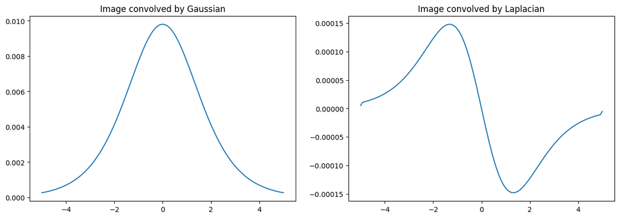

```python
f, ax = plt.subplots(1,2)
f.set_figwidth(15)
ax[0].plot(x, np.gradient(denoised_y))
ax[0].title.set_text("Image convolved by Gaussian")
ax[1].plot(x, np.gradient(np.gradient(denoised_y)))
ax[1].title.set_text("Image convolved by Laplacian")
```

The zero-crossing in the image convolved by the second-derivative indicates edge.

## Gaussians and its derivatives

$\nabla^2{f} = \frac{\partial^2{f}}{\partial{x^2}} + \frac{\partial^2{f}}{\partial{y^2}}$

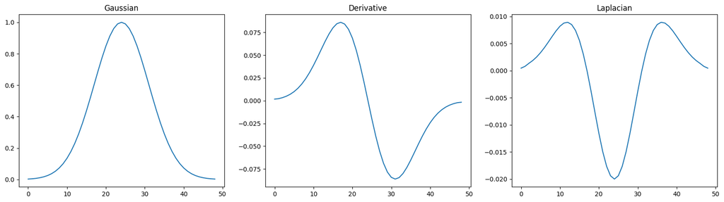

```python
from scipy import signal
gs = signal.gaussian(49, 7)
dr = np.gradient(gs)
la = np.gradient(dr)

f, ax = plt.subplots(1, 3)
f.set_figheight(5)
f.set_figwidth(20)
ax[0].plot(gs)
ax[0].title.set_text("Gaussian")

ax[1].plot(dr)
ax[1].title.set_text("Derivative")

ax[2].plot(la)
ax[2].title.set_text("Laplacian")
```

## Criteria for Good Detector

1. **Good Detection**: Find real edges ignoring noise or other artifacts
2. **Good Localization**: Detect edges as close as possible to true edges
3. **Single Response**: Return one point only for each true edge point

## Non-Maxima Supression

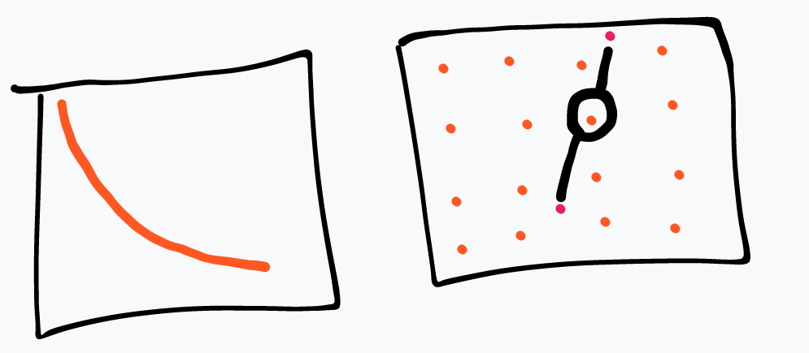

Assume the orange curve is the edge of an image and is full of noise, we would supress that noise by:

- Check if a pixel is the local maximum along the graident direction.
- May require checking the intensities of interpolatex pixels, as drawn in the image.
- My understanding is this process would result in us picking out 1 pixel over a group of pixels(as shown in the right image)

## Hysterisis Thresholding

A technique to handle discontinuities.  
**Check for well-connected egdes**. *How?*  
Use high-threshold to start edges curves and low threshold to continue them

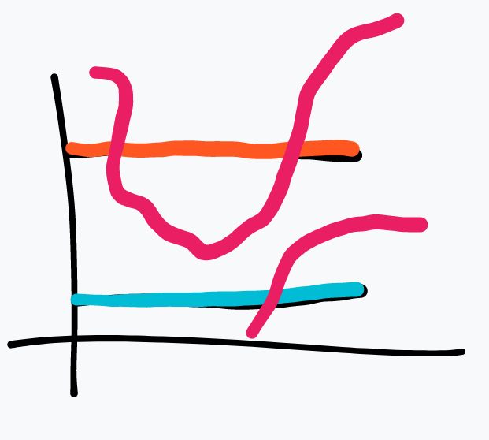

- If gradient at pixel > 'High' = **Edge Pixel**
- If gradient at pixel < 'Low' = **Non-Edge Pixel**
- If gradient at pixel >= 'Low' and <= 'High' = **Edge Pixel** iff it is connected to an edge pixel directly or via pixels between 'low' and 'high'.

## Canny Edge Detection

1. Filter the image with derivative of Gaussian
2. Find Maginitude and Orientation of Gradient
3. Non-Maxima Supression
4. Do Hysterisis (AKA Double Thresholding and Edge Tracking)

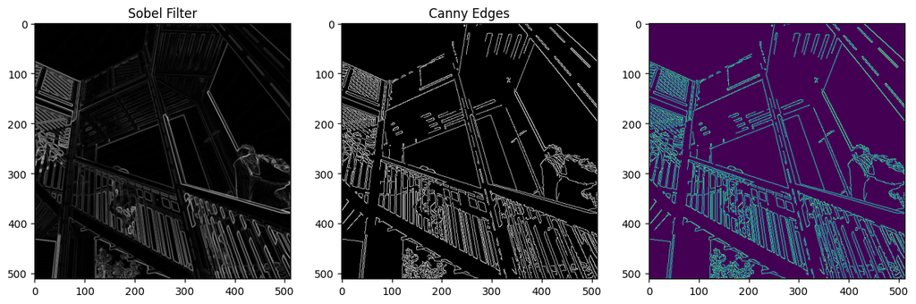

```python
canny_edges = cv.Canny(np.uint8(ascent),100,200, apertureSize=3)
f, ax = plt.subplots(1, 3)
f.set_figwidth(15)
ax[0].imshow(magnitude, cmap='gray')
ax[0].title.set_text("Sobel Filter")
ax[1].imshow(canny_edges, cmap='gray')
ax[1].title.set_text("Canny Edges")
ax[2].imshow(canny_edges)
```

### Effect of $\sigma$ in Canny Edge Detector

- Large $\sigma$ detects large-scale edges
- Small $\sigma$ detects fine edges

### Straight-line Detection using Canny edges

1. Compute Canny Edges
2. Assign each edge pixel to one of the 8 directions
3. For each direction 'd', get edgelets.
   - Find connected components for edge pixels with directions {d-1, d, d+1}
4. For each edgelet, compute the straightness and orientation using the second moment matrix *M* of the edge pixels

$$ M = \begin{bmatrix} \Sigma(x-\mu_x)^2 & \Sigma(x-\mu_x)(y - \mu_y) \\ \Sigma(x-\mu_x)(y - \mu_y) & \Sigma(y-\mu_y)^2 \end{bmatrix} $$

- $\theta = tan^{-1}(\frac{v_1}{v_0})$, where $v_1$ is the eigenvector corresponding to the largest eigenvalue
- straightness = $\frac{\lambda_2}{\lambda_1}$, where $\lambda_1$ is the largest eigenvalue
5. Threshold straightness appropriately and store line segments

## Laplacian of Gaussian

*Discrete approximation of Second-Derivative*
$$ \frac{\partial^2{f}}{\partial{x^2}} = f(x+1, y) + f(x-1, y) - 2f(x, y) \\ \frac{\partial^2{f}}{\partial{y^2}} = f(x, y+1) + f(x, y-1) - 2f(x, y) $$ Substituting in Laplacian Operator $$ f(x+1, y) + f(x-1, y) + f(x, y+1) + f(x, y-1) - 4f(x,y) \\ \begin{bmatrix} 0 & 1 & 0 \\ 1 & -4 & 1 \\ 0 & 1 & 0\end{bmatrix} $$

```python
def gaussian_kernel(size: int, sigma: float) -> np.ndarray:
    """Generates a (size x size) Gaussian kernel."""
    kernel = np.fromfunction(
        lambda x, y: (1/(2*np.pi*sigma**2)) * np.exp(-((x-(size-1)/2)**2 + (y-(size-1)/2)**2) / (2*sigma**2)),
        (size, size)
    )
    return kernel / np.sum(kernel)

gaussian_kernel_31x31 = gaussian_kernel(31, 5)
```

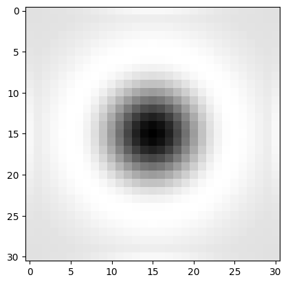

```python
log = laplace(gaussian_kernel_31x31)

plt.imshow(log, cmap='gray')

gaussian_kernel_17x17 = gaussian_kernel(17, 5)
log = laplace(gaussian_kernel_17x17)
```

### Laplacian of Gaussian as a Blob Detector

Convolution with a filter can be viewed as comparing a little image of what you want to find against all the local regions of the image.

Since, LoG as an image looks like a Blob, it can be used for blob detection.

```python
sunflower = cv2.imread('sunflower.jpg', cv2.IMREAD_GRAYSCALE)
```

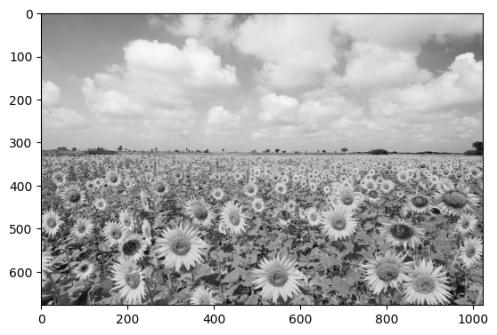

```python
plt.imshow(sunflower, cmap='gray')
```

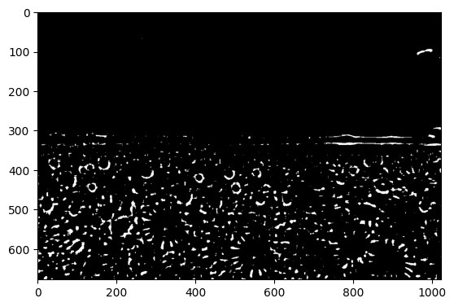

```python
plt.imshow(convolve(sunflower, log), cmap='gray')
```

## From Blobs to Corners:

**Motivation**: What are the interesting features that set apart an image from every other image?

**Possible Solution**:

1. Look for image regions that are unusual.
2. Textureless patches are nearly impossible to Localize. (Eg: Sky)
3. Patches with large contrast changes (gradients) are easier to localize (Edges)
4. But *edges* suffer from **aperture problem**
5. Significant Gradients in atleast 2 different orientations are the easiest (Eg: Corners)

#### Aperture Problem:

A feature may appear as 2 different things in 2 different scales(??)

- In a "flat": No Change in Grad in all directions
- In a "edge": No Change in Grad in the direction of the edge
- In a "corner": Change in Grad in all directions

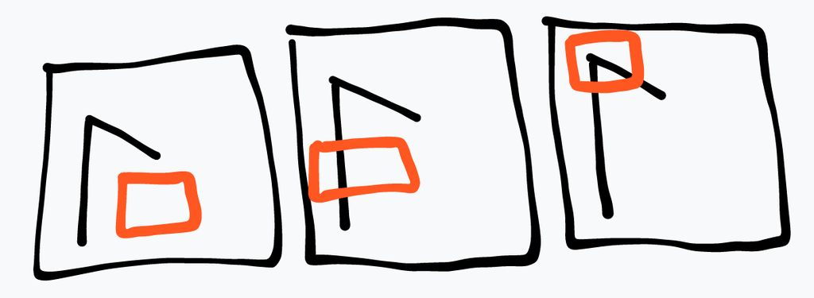

## Autocorrelation

Correlation with itself  
$ E_{AC}[\Delta{u}] = \Sigma_{x,y} W(P_i)[I(P_i + \partial{u}) - I(P_i)]^2 $, in other words: Sum of change in pixel intensities as we move the patch

$W(P_i)$ is the window function

**Taylor Series Expansion** of $I[P_i + \Delta{u}] = I(P_i) + \nabla{I}(P_i)\Delta{u}$, where $\Delta{u}$ indicates the shift.

Therefore, $$ E_{AC}[\Delta{u}] = \Sigma_{x,y} W(P_i)[I(P_i + \partial{u}) - I(P_i)]^2 \\ \approx \Sigma_{x,y} W(P_i)[I(P_i) + \nabla{I}(P_i)\Delta{u} - I(P_i)]^2 \\ \approx \Sigma_{x,y} W(P_i)[\nabla{I}(P_i)\Delta{u}]^2 \\ \approx \Delta{u^T} A \Delta{u} $$

$$ A = \Sigma_u\Sigma_v W(u,v) \begin{bmatrix} I_x^2 & I_xI_y \\ I_xI_y & I_y^2\end{bmatrix} \\ = W *\begin{bmatrix} I_x^2 & I_xI_y \\ I_xI_y & I_y^2\end{bmatrix} \\ = U \begin{bmatrix} \lambda_1 & 0 \\ 0 & \lambda_2 \end{bmatrix} U^T $$

**A** tells us how much did the gradients change as the position of the patch is changed and the *eigenvalues of A* reveal the amount of intensity change in the two principal orthogonal directions in the window.

**How do eigenvalues determine if an image point is a corner?*

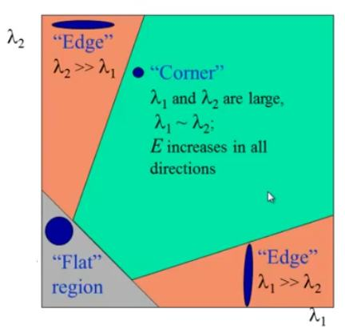

## Harris Corner Detector

a. Compute gradients at each point in the image.  
b. Compute **A** for each image window to get its cornerness score  
c. Compute eigenvalues or Compute $M_c$, where $M_c = \lambda_1\lambda_2 - k(\lambda_1 + \lambda_2)^2$ = $det - k * trace^2$  
d. Find points who have **$M_c > threshold$**  
e. Perform non-maxima supression of the points

### Variants of $M_c$

1. The $M_c$ given above. It is rotationally-invariant and downweights edge-like features
2. Triggs '04 = $\lambda_0 - \alpha \lambda_1$
3. Brown '05 = User Harmonic Mean, $\frac{det(A)}{trace(A)} = \frac{\lambda_0\lambda_1}{\lambda_0 + \lambda_1}$

### Properties

1. Not scale-invariant. If the image is zoomed-in, a pixel may be detected as an edge, but would be detected as corner, if the image is sufficiently zoomed-out. Add Image(??)
2. Rotation Invariant - Yes
3. Shift-Invariant($I = I + b$)- Yes, since only gradients(derivatives) are used.
4. Photometric Change($I = aI + b$) - Partially invariant (Based on the chosen threshold)

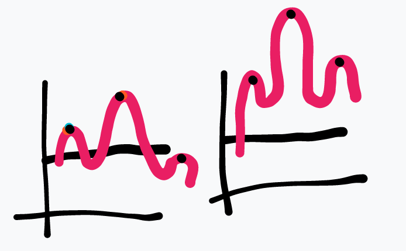

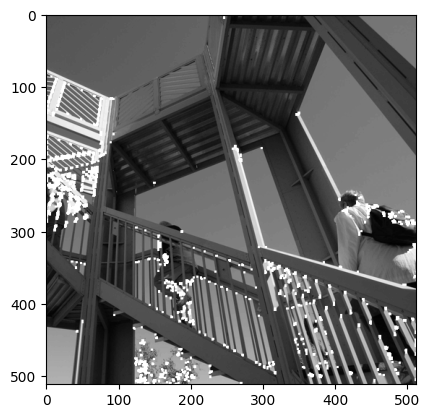

```python
## Implementation
gray = ascent.astype("uint8")
dst = cv.cornerHarris(gray, 2, 3, 0.04)
dst = cv.dilate(dst, None)
gray[dst>0.01*dst.max()]=255
plt.imshow(gray, cmap='gray')
```

## Selecting scale-invariant interest points

How can we select interest points in each image such that the detections are repeatable across different scales?

1. Plot the region size vs corner measure.
2. Find the regions in both the image which have peaks

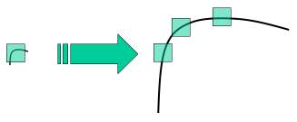

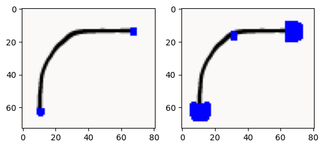

```python
filename = 'harris.png'
img = cv.imread(filename)
img_ = cv.imread(filename)

gray = cv.cvtColor(img,cv.COLOR_BGR2GRAY)
gray = np.float32(gray)
dst = cv.cornerHarris(gray,2,3,0.04)
dst_ = cv.cornerHarris(gray,10,3,0.04)
#result is dilated for marking the corners, not important
dst = cv.dilate(dst, None)
dst_ = cv.dilate(dst_, None)

# Threshold for an optimal value, it may vary depending on the image.
img[dst>0.1*dst.max()]=[0,0,255]
img_[dst_>0.1*dst_.max()] = [0,0,255]

f, ax = plt.subplots(1,2)
ax[0].imshow(img)
ax[1].imshow(img_)
```

## Automatic Scale Selection

Design a function that takes a region around the point and outputs its response as a scalar given the region.  
We will observe that the function outputs different response values depends on the region size. And more importantly, the local maxima of this function is a strong clue indicating that the region size corresponding to the local maxima should be invariant to image scale.

## Textures

Regular or stochastic patterns caused by bumps, grooves or markings.  
**Why care about textures?** Conveys more information that can be exploited to match regions of interest in images.  
**How to represent textures?** Compute responses of blobs and edges at various orientations and scales.

## Filter Banks

1. They have multiple filters that only allow certain frequencies.
2. They seperate the input signal into multiple components
3. Each component carrying a single freq. sub-band of the original signal.
4. Then, Process the image with each filter.

*Examples*: Gabor, Steerable, Isotropic Gaussian

### Gabor

*A special class of band-pass filters. They mimic the human visual system*  
It can be viewed as a product of the convolution between **gaussian** wave and a **sinusoidal** signal with a certain frequency and modulation.

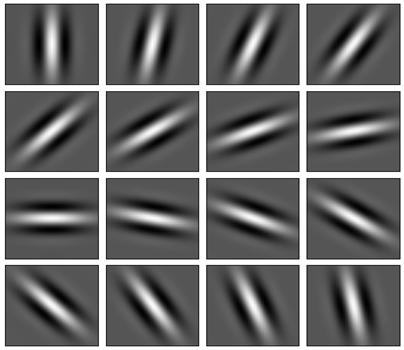

### Steerable Filter

A class of oriented filters that can be steered or expressed as a linear combination of a set of basis filters.